# 512-hw3

Jieyi Sun

3/13/2022

## Problem 1: Use polynomials and ridge regression to predict stock returns

This problem uses the built in EuStockMarkets dataset. The dataset contains time series of closing prices of major European stock indices from 1991 to 1998. We use only the FTSE column in this problem. The dataset is a time series object, but you will need to extract the FTSE column and make it into a data frame.

```r
data("EuStockMarkets")
FTSE <- EuStockMarkets[,4]
Time <- as.numeric(time(EuStockMarkets))
df <- data.frame(Time, FTSE)
```

part a: Fit polynomial models of degrees 4, 8, 12 to the FTSE data and plot all three fitted curves together with a scatterplot of the data. Comment on the plots. Which features in the data are resolved by the polynomial models? Which features are not resolved? Do the polynomial curves show any artifacts such as oscillations?

```r
degree4 <- lm(FTSE~poly(Time, 4), data = df)
degree8 <- lm(FTSE~poly(Time, 8), data = df)
degree12 <- lm(FTSE~poly(Time, 12), data = df)
pred1 <- predict(degree4)
pred2 <- predict(degree8)
pred3 <- predict(degree12)
```

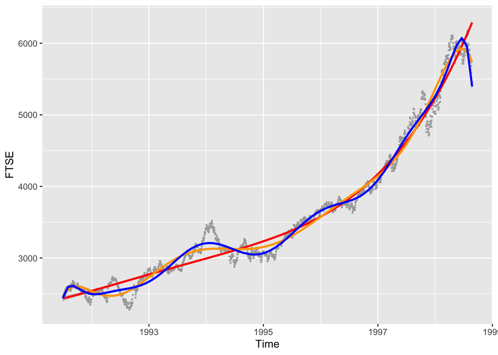

```r
library(ggplot2)

ggplot(data = df, aes(x=Time, y=FTSE)) +
  geom_point(lwd=0.3, color="darkgrey") +
  geom_smooth(method = 'lm', formula = y~poly(x, 4), color = "red") +
  geom_smooth(method = 'lm', formula = y~poly(x, 8), color = 'orange')+
  geom_smooth(method = 'lm', formula = y~poly(x, 12), color = 'blue')
```

part b: Use ridge regression to regularize the polynomial model of degree 12. Use λ1SE. Plot the resulting polynomial model onto the the data and comment on it.

```r
library(glmnet)
df1 <- data.frame(poly(Time, 12)[,1:12])
df1$FTSE <- FTSE
set.seed(123)
train <- sample(nrow(df1), 0.8*nrow(df1))
X <- model.matrix(FTSE~.,data = df1)
X[,2:13] <- scale(X[,2:13])
X.train <- X[train,]
X.predict <- X[-train,]
Y.train <- df$FTSE[train]
Y.predict <- df$FTSE[-train]
# Find the best lambda using cross-validation
cv.ridge=cv.glmnet(X.train,Y.train,alpha = 0)
# Display the value of lambda 1se
lambda=cv.ridge$lambda.1se
# Fit the regularized model on the training data
model.ridge<-glmnet(df1[,1:12],df1[,13],lambda = lambda)
```

```r
# Display regression coefficients
coef(model.ridge)
```

```
## 13 x 1 sparse Matrix of class "dgCMatrix"
##                    s0
## (Intercept)  3565.643
## X1          34889.909
## X2           9585.292
## X3           2165.875
## X4              .
## X5              .
## X6              .
## X7              .
## X8              .
## X9              .
## X10             .
## X11             .
## X12             .
```

```r
degree12$coefficients<-coef(model.ridge)[,1]
degree12
```

```
##
## Call:
## lm(formula = FTSE ~ poly(Time, 12), data = df)
##
## Coefficients:
## (Intercept)           X1           X2           X3           X4           X5
##        3566        34890         9585         2166            0            0
##          X6           X7           X8           X9          X10          X11
##           0            0            0            0            0            0
##         X12
##           0
```

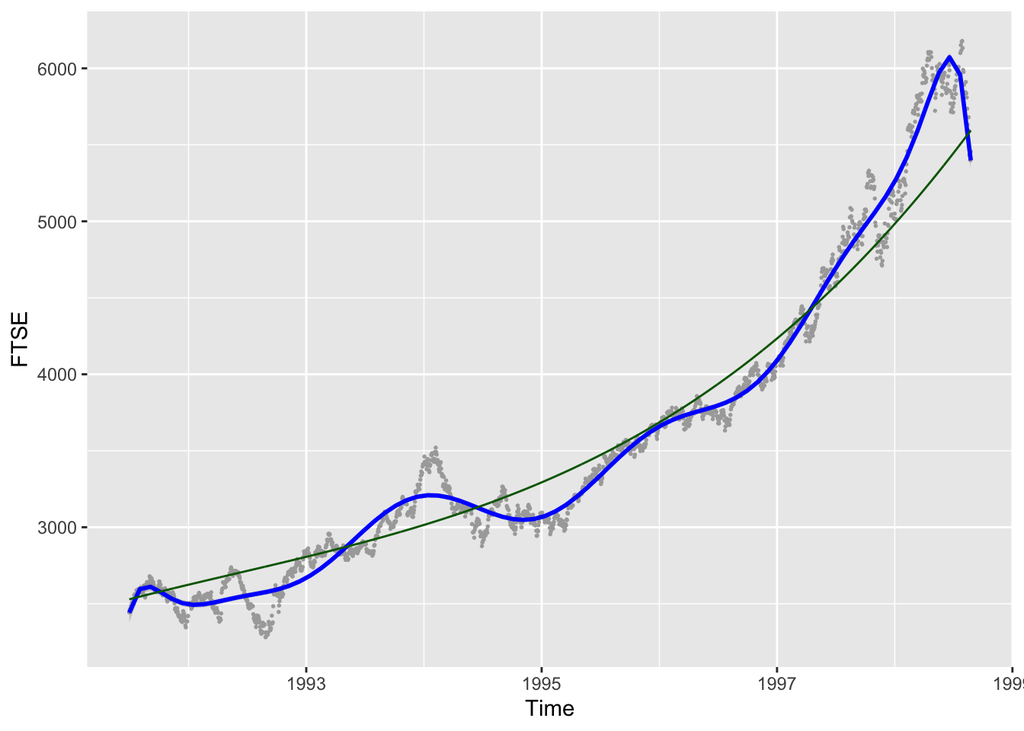

```r
ggplot(data=df, aes(x=Time, y=FTSE)) +
  geom_point(lwd=0.3, color="darkgrey") +
  geom_smooth(method = 'lm', formula = y~poly(x, 12), color = 'blue') +
  geom_line(color = "darkgreen", aes(x = Time, y = predict(degree12)))
```

## Problem 2: Improve advertising budgets using GAMs

Use the Advertising dataset, which can either be found here. Split the data into a training and test set (70% / 30%).

```r
set.seed(123)
ad<-read.csv("~/Desktop/512/512-hw3/Advertising.csv")
ad<-ad[,2:5]
train2<-sample(nrow(ad),0.7*nrow(ad))
train.data<-ad[train2,]
test.data<-ad[-train2,]
```

part a: Fit generalized additive models to predict sales, using smoothing splines of degrees 2, 3, 4, 5, 6 for the three predictors. How do the rms prediction errors compare to the rms prediction error of a multiple regression model on the training set? On the test set?

```r
library(gam)
library(Metrics)
lm <- lm(Sales~TV+Radio+Newspaper, data = ad)
gam2 <- gam(Sales~ s(TV, 2) + s(Radio, 2) + s(Newspaper, 2) , data=ad)
gam3 <- gam(Sales~ s(TV, 3) + s(Radio, 3) + s(Newspaper, 3) , data=ad)
gam4 <- gam(Sales~ s(TV, 4) + s(Radio, 4) + s(Newspaper, 4) , data=ad)
gam5 <- gam(Sales~ s(TV, 5) + s(Radio, 5) + s(Newspaper, 5) , data=ad)
gam6 <- gam(Sales~ s(TV, 6) + s(Radio, 6) + s(Newspaper, 6) , data=ad)
```

```r
# compare rms prediction errors to the rms prediction error of a multiple regression model
#on the training set
r=rmse(train.data$Sales, predict(lm, train.data))
r2=rmse(train.data$Sales, predict(gam2, train.data))
r3=rmse(train.data$Sales, predict(gam3, train.data))
r4=rmse(train.data$Sales, predict(gam4, train.data))
r5=rmse(train.data$Sales, predict(gam5, train.data))
r6=rmse(train.data$Sales, predict(gam6, train.data))
r_train=data.frame(r,r2,r3,r4,r5,r6)
r_train
```

```
##          r       r2       r3       r4       r5       r6
## 1 1.732739 1.536323 1.464043 1.420952 1.382461 1.346144
```

```r
# on the test set
R=rmse(test.data$Sales, predict(lm, test.data))
R2=rmse(test.data$Sales, predict(gam2, test.data))
R3=rmse(test.data$Sales, predict(gam3, test.data))
R4=rmse(test.data$Sales, predict(gam4, test.data))
R5=rmse(test.data$Sales, predict(gam5, test.data))
R6=rmse(test.data$Sales, predict(gam6, test.data))
r_test=data.frame(R,R2,R3,R4,R5,R6)
r_test
```

```
##          R       R2       R3      R4       R5      R6
## 1 1.508262 1.366119 1.302279 1.26946 1.252649 1.23795
```

part b: Is there evidence of overfitting?

No. The train rmse is higher than the test rmse.

part c: You now have six models (five GAM and one LM). Which model should be used? Explain your answer.

The GAM with smoothing spline degree of 6 should be used, because it has the lowest test rmse.

### Problem 3: Use LASSO to predict housing prices in Boston

Consider the Boston data from the MASS package. We want to use LASSO to predict the median home value medv using all the other predictors.

```r
library(MASS)
data("Boston")
Boston=Boston
```

part a: Set up the LASSO and plot the trajectories of all coefficients. What are the last five variables to remain in the model?

```r
# Split the data into training and test set set.seed(123)
library(dplyr)
library(tidyverse)
library(caret)
training.samples <- Boston$medv %>%
  createDataPartition(p = 0.8, list = FALSE)
train.data <- Boston[training.samples, ]
test.data <- Boston[-training.samples, ]
```

```r
# Predictor variables
x_train <- model.matrix(medv~., train.data)[,-1]
x_test<-model.matrix(medv~., test.data)[,-1]
# Outcome variable
y_train <- train.data$medv
y_test <- test.data$medv
```

```r
lasso_fit <- train(x = x_train, y = y_train,
                   method = 'glmnet',
                   trControl = trainControl(method = 'cv', number = 10),
                   tuneGrid = expand.grid(alpha = 1,
                                          lambda = seq(0.001, 1, length.out = 100)),
                   preProcess = c('center', 'scale'))

(lasso_info <- postResample(predict(lasso_fit, x_test), y_test))
```

```
##      RMSE  Rsquared       MAE
## 4.9176741 0.7594554 3.3031810
```

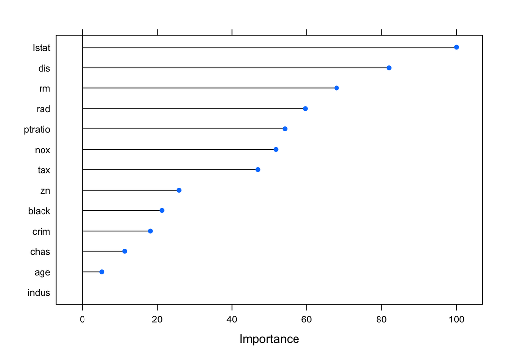

```r
plot(varImp(lasso_fit))
```

```r
#the last five variables to remain in the model are: Istat, dis, rm, rad, ptratio
```

```r
coef=coef(lasso_fit$finalModel, lasso_fit$bestTune$lambda)
coef
```

```
## 14 x 1 sparse Matrix of class "dgCMatrix"
##                     s1
## (Intercept) 22.3894349
## crim        -0.6813571
## zn           0.9699442
## indus        .
## chas         0.4220444
## nox         -1.9402279
## rm           2.5490625
## age         -0.1951103
## dis         -3.0757120
## rad          2.2366008
## tax         -1.7611531
## ptratio     -2.0300088
## black        0.7958584
## lstat       -3.7491519
```

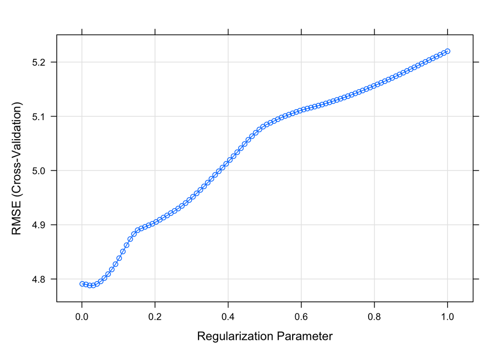

```r
#plot the trajectories of all coefficients
plot(lasso_fit)
```

part b:Find the 1SE value of λ, using 10-fold cross-validation. What is the cross validation estimate for the residual standard error?

```r
cv.lasso=cv.glmnet(x_train,y_train,alpha=1) #default is 10
lambda.1se=cv.lasso$lambda.1se
lambda.1se
```

```
## [1] 0.4956975
```

```r
i0<-which(cv.lasso$lambda==lambda.1se)
rmse<-cv.lasso$cvm[i0]
rmse
```

```
## [1] 27.27326
```

part c: Rescale all predictors so that their mean is zero and their standard deviation is 1. Then set up the LASSO and plot the trajectories of all coefficients. What are the last five variables to remain in the model? Compare your answer to part a.

```r
crim.scaled=scale(Boston$crim,center = T,scale = T)
zn.scaled=scale(Boston$zn,center = T,scale = T)
indus.scaled=scale(Boston$indus,center = T,scale = T)
chas.scaled=scale(Boston$chas,center = T,scale = T)
nox.scaled=scale(Boston$nox,center = T,scale = T)
rm.scaled=scale(Boston$rm,center = T,scale = T)
age.scaled=scale(Boston$age,center = T,scale = T)
dis.scaled=scale(Boston$dis,center = T,scale = T)
rad.scaled=scale(Boston$rad,center = T,scale = T)
tax.scaled=scale(Boston$tax,center = T,scale = T)
ptratio.scaled=scale(Boston$ptratio,center = T,scale = T)
black.scaled=scale(Boston$black,center = T,scale = T)
lstat.scaled=scale(Boston$lstat,center = T,scale = T)
medv.scaled=scale(Boston$medv,center = T,scale = T)

Boston.scaled<-data.frame(crim.scaled,zn.scaled,indus.scaled,chas.scaled,nox.scaled,rm.scaled,age.scaled,dis.scaled,rad.scaled,tax.scaled,ptratio.scaled,black.scaled,lstat.scaled,medv.scaled)
```

```r
# Split the data into training and test set
set.seed(123)
training.samples.scaled <- Boston.scaled$medv.scaled %>%
  createDataPartition(p = 0.8, list = FALSE)
train.data.scaled <- Boston.scaled[training.samples.scaled, ]
test.data.scaled <- Boston.scaled[-training.samples.scaled, ]
```

```r
# Predictor variables
x_train <- model.matrix(medv.scaled~., train.data.scaled)[,-1]
x_test<-model.matrix(medv.scaled~., test.data.scaled)[,-1]
# Outcome variable
y_train <- train.data.scaled$medv.scaled
y_test <- test.data.scaled$medv.scaled
```

```r
lasso_fit <- train(x = x_train, y = y_train,
                   method = 'glmnet',
                   trControl = trainControl(method = 'cv', number = 10),
                   tuneGrid = expand.grid(alpha = 1,
                                          lambda = seq(0.001, 1, length.out = 100)),
                   preProcess = c('center', 'scale'))
(lasso_info <- postResample(predict(lasso_fit, x_test), y_test))
```

```
##      RMSE  Rsquared       MAE
## 0.4987503 0.7619428 0.3659591
```

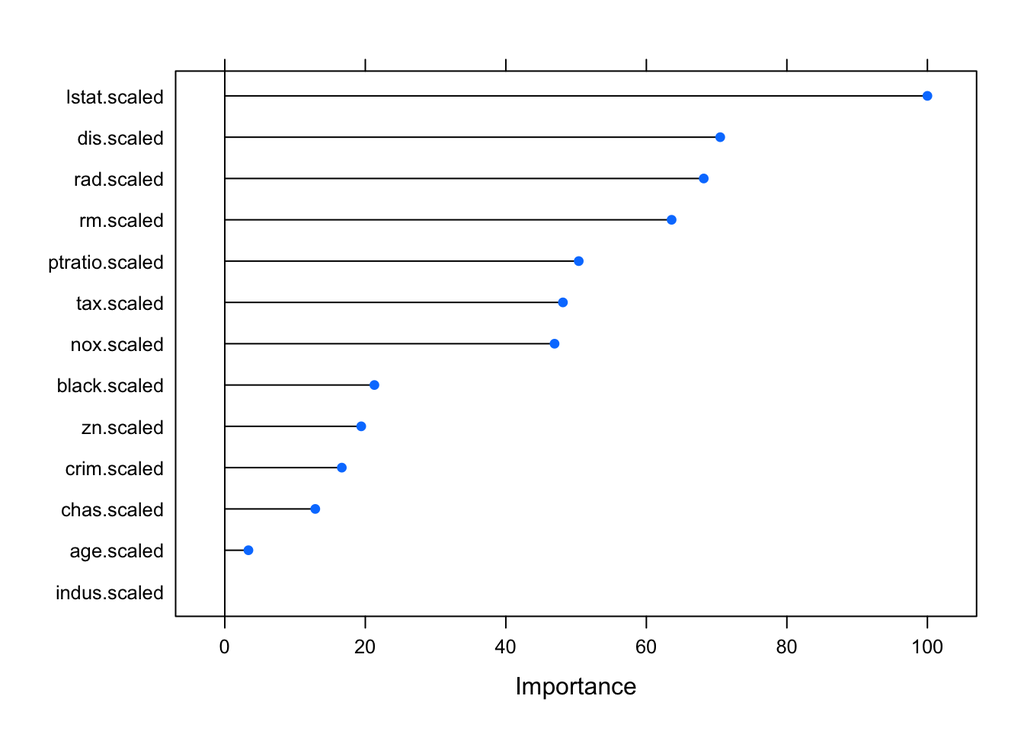

```r
plot(varImp(lasso_fit))
```

```r
#the last five variables to remain in the model are: Istat, dis, rad, rm, ptratio
```

```r
coef=coef(lasso_fit$finalModel, lasso_fit$bestTune$lambda)
coef
```

```
## 14 x 1 sparse Matrix of class "dgCMatrix"
##                          s1
## (Intercept)    -0.002418284
## crim.scaled    -0.081148711
## zn.scaled       0.092853183
## indus.scaled   -0.010670205
## chas.scaled     0.065170431
## nox.scaled     -0.209306199
## rm.scaled       0.279813414
## age.scaled      0.024902824
## dis.scaled     -0.309105295
## rad.scaled      0.299175710
## tax.scaled     -0.214352457
## ptratio.scaled -0.223872694
## black.scaled    0.100781633
## lstat.scaled   -0.433906758
```

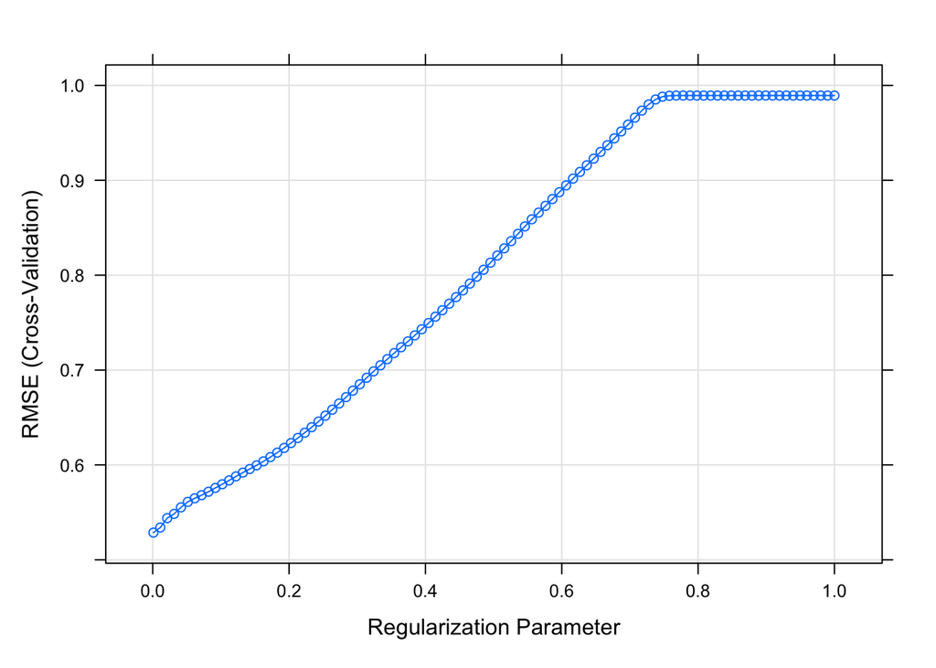

```r
#plot the trajectories of all coefficients
plot(lasso_fit)
```

part d: Find the 1SE value of λ using 10-fold cross-validation. What is the cross validation estimate for the residual standard error now? Does rescaling lead to a better performing model?

```r
cv.lasso=cv.glmnet(x_train,y_train,alpha=1) #default is 10
lambda.1se=cv.lasso$lambda.1se
lambda.1se
```

```
## [1] 0.07932159
```

```r
i0<-which(cv.lasso$lambda==lambda.1se)
rmse<-cv.lasso$cvm[i0]
rmse # Yes, rescaling leads to a better performing model because the residual standard error is much less than unscaling.
```

```
## [1] 0.3398842
```

### Problem 4:Predict bike share usage in Seoul using ridge and LASSO regressions

Access the dataset here. Filter the data to only include rows with “functioning days” == ‘Yes’. Next drop the columns Date, Hour, Seasons, and Holiday, and Functioning Day. Then drop any rows that have any missing values in any columns. Hint: You will need to rename some of the variable names because they include non-ASCII characters. This will help you later on.

```r
bike<-read.csv("~/Desktop/512/512-hw3/SeoulBikeData.csv")
```

```r
data<-subset(bike,Functioning.Day=='Yes')
data<-data[,-c(1,3,12,13,14)]
data<-na.omit(data)
```

part a: Run a linear regression to predict rented bike count using the remaining 8 variables in the dataset. Report the MSE and the most influential variables.

```r
# Split the data into training and test set
set.seed(123)
training.samples<-data$Rented.Bike.Count %>%
  createDataPartition(p=0.8, list = FALSE)

train.data<-data[training.samples,]
test.data<-data[-training.samples,]
```

```r
model1<-lm(Rented.Bike.Count~Temperature + Humidity + Wind.speed + Visibility + Dew.point.temperature + Solar.Radiation + Rainfall + Snowfall, data = train.data)
summary(model1)
```

```
##
## Call:
## lm(formula = Rented.Bike.Count ~ Temperature + Humidity + Wind.speed +
##     Visibility + Dew.point.temperature + Solar.Radiation + Rainfall +
##     Snowfall, data = train.data)
##
## Residuals:
##      Min       1Q   Median       3Q      Max
## -1353.01  -295.24   -56.89   202.38  2326.29
##
## Coefficients:
##                         Estimate Std. Error t value Pr(>|t|)
## (Intercept)            8.144e+02  1.129e+02   7.216 5.94e-13 ***
## Temperature            3.846e+01  4.440e+00   8.662  < 2e-16 ***
## Humidity              -1.005e+01  1.257e+00  -7.995 1.52e-15 ***
## Wind.speed             5.557e+01  6.228e+00   8.923  < 2e-16 ***
## Visibility            -3.519e-03  1.210e-02  -0.291   0.7711
## Dew.point.temperature -1.907e+00  4.683e+00  -0.407   0.6838
## Solar.Radiation       -1.192e+02  9.550e+00 -12.477  < 2e-16 ***
## Rainfall              -6.289e+01  5.898e+00 -10.663  < 2e-16 ***
## Snowfall               3.380e+01  1.335e+01   2.532   0.0114 *
## ---
## Signif. codes:  0 '***' 0.001 '**' 0.01 '*' 0.05 '.' 0.1 ' ' 1
##
## Residual standard error: 484.3 on 6765 degrees of freedom
## Multiple R-squared:  0.4328, Adjusted R-squared:  0.4322
## F-statistic: 645.3 on 8 and 6765 DF,  p-value: < 2.2e-16
```

```r
#make prediction
prediction<-model1 %>% predict(test.data)
```

```r
#model performance
RMSE(prediction,test.data$Rented.Bike.Count)
```

```
## [1] 483.8762
```

part b: Fit a ridge regression model with the optimal λ chosen by cross validation. Report the CV MSE.

```r
# Predictor variables
x_train <- model.matrix(Rented.Bike.Count~., train.data)[,-1]
x_test<-model.matrix(Rented.Bike.Count~., test.data)[,-1]
# Outcome variable
y_train <- train.data$Rented.Bike.Count
y_test <- test.data$Rented.Bike.Count
```

```r
ridge_fit <- train(x = x_train, y = y_train,
                   method = 'glmnet',
                   trControl = trainControl(method = 'cv', number = 10),
                   tuneGrid = expand.grid(alpha = 0,
                                          lambda = seq(0.001, 1, length.out = 100)),
                   preProcess = c('center', 'scale'))

(ridge_info <- postResample(predict(ridge_fit, x_test), y_test))
```

```
##        RMSE    Rsquared         MAE
## 484.9235109   0.4281201 361.9368921
```

part c: Perform the same fit using a LASSO regression this time. Choose the optimal λ using cross validation. Report on the remaining variables in the model and the CV MSE. How does this performance compare to ridge and a plain linear model?

```r
lasso_fit <- train(x = x_train, y = y_train,
                   method = 'glmnet',
                   trControl = trainControl(method = 'cv', number = 10),
                   tuneGrid = expand.grid(alpha = 1,
                                          lambda = seq(0.001, 1, length.out = 100)),
                   preProcess = c('center', 'scale'))

(lasso_info <- postResample(predict(lasso_fit, x_test), y_test))
```

```
##        RMSE    Rsquared         MAE
## 483.7163640   0.4304095 362.1225600
```

```r
#Compared with their RMSE, the performance of LASSO regression is better than ridge  and a plain linear model.
```

part e: Interpretion and communication. Write a short paragraph about your analysis and recommendations, explaining the most important factors for high bike share usage, why you came to that conclusion, and what actions can be taken by a bike rental company based on this information.

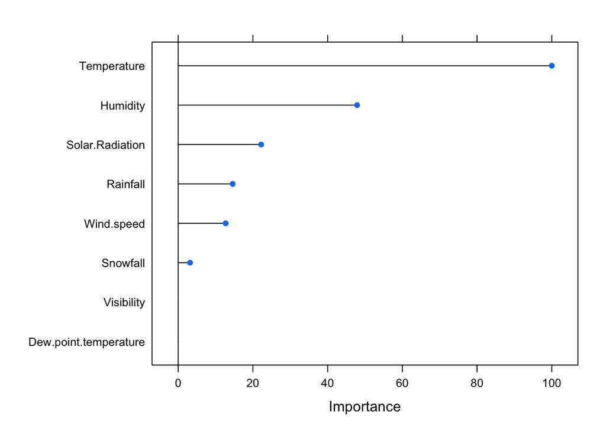

```r
plot(varImp(lasso_fit))
```

```r
# Temperature contributes to Rented Bike Counts most. The most important factors: Temperature, humidity, solar radiation, rainfall, wind speed, snowfall.
```

### Problem 5: Compare the characteristics of two different smoothing splines

part a:  
The g hat 2 will have smaller RSS. Because as λ→∞, the penalty term will become more important. So, g hat 1 will be the quadratic that minimizes the training RSS and g hat 2 will be a will be the cubic that minimizes the training RSS. g hat 2 will be more flexible so it has smaller training RSS.

part b: It is hard to tell because the relationship between x and y is unknown.

part c: The penalty term can be ignored when lambda = 0. The g hat 1 and g hat 2 will have the same training and test RSS.

### Problem 6: Explain the behavior of the curve for a variety of λ and m values.

Use the following starter code to make your set of points and plot your various model predictions.

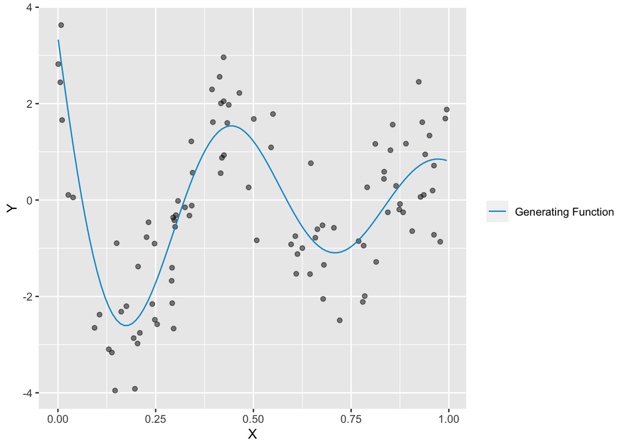

```r
set.seed(325626)
X <- runif(100)
eps <- rnorm(100)
Y <- sin(12*(X + 0.2)) / (X + 0.2) + eps
generating_fn <- function(X) {sin(12*(X + 0.2)) / (X + 0.2)}
df <- data.frame(X, Y)

ggplot(df, aes(x = X, y = Y)) +
  geom_point(alpha = 0.5) +
  stat_function(fun = generating_fn, aes(col = "Generating Function")) +
  scale_color_manual(values = "deepskyblue3") +
  theme(legend.position = "right", legend.title = element_blank())
```

1. $λ=∞,m=0$

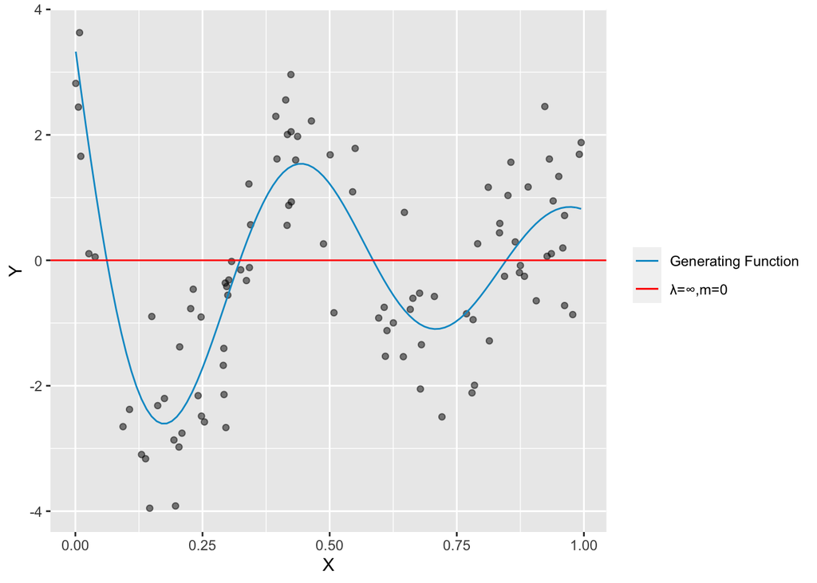

```r
ggplot(df, aes(x = X, y = Y)) +
  geom_point(alpha = 0.5) +
  stat_function(fun = generating_fn, aes(col = "Generating Function")) +
  geom_hline(aes(yintercept = 0, col = "λ=∞,m=0"))+
  scale_color_manual(values =c("deepskyblue3", "red")) +
  theme(legend.position = "right", legend.title = element_blank())
```

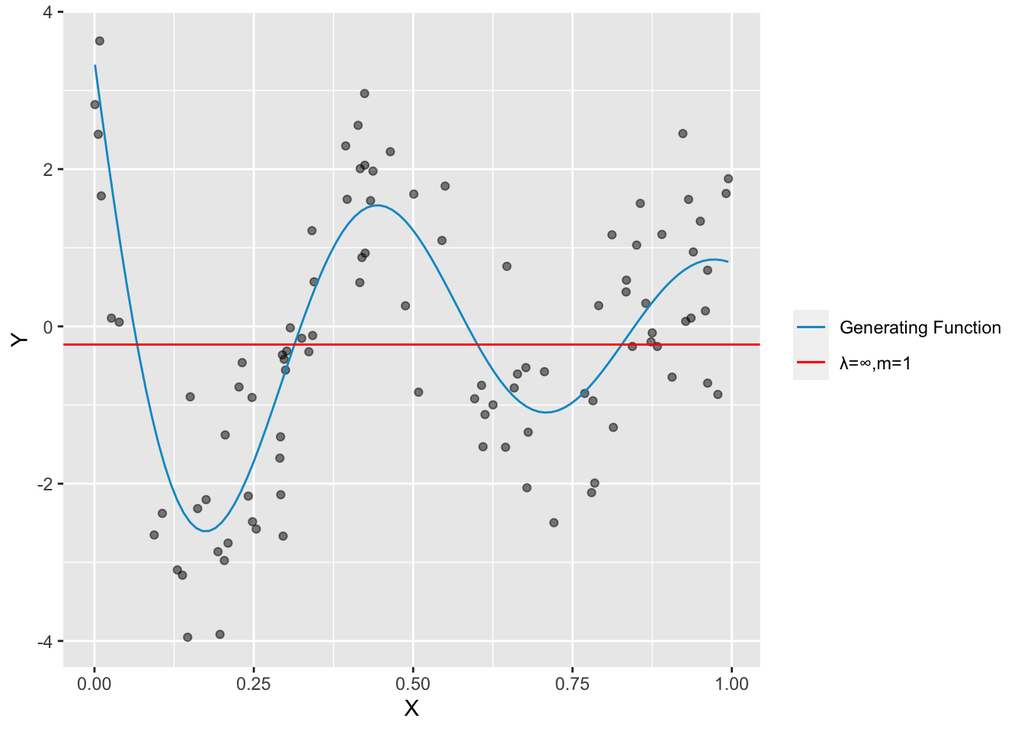

```r
ggplot(df, aes(x = X, y = Y)) +
  geom_point(alpha = 0.5) +
  stat_function(fun = generating_fn, aes(col = "Generating Function")) +
  geom_hline(aes(yintercept = mean(Y), col = "λ=∞,m=1"))+
  scale_color_manual(values =c("deepskyblue3", "red")) +
  theme(legend.position = "right", legend.title = element_blank())
```

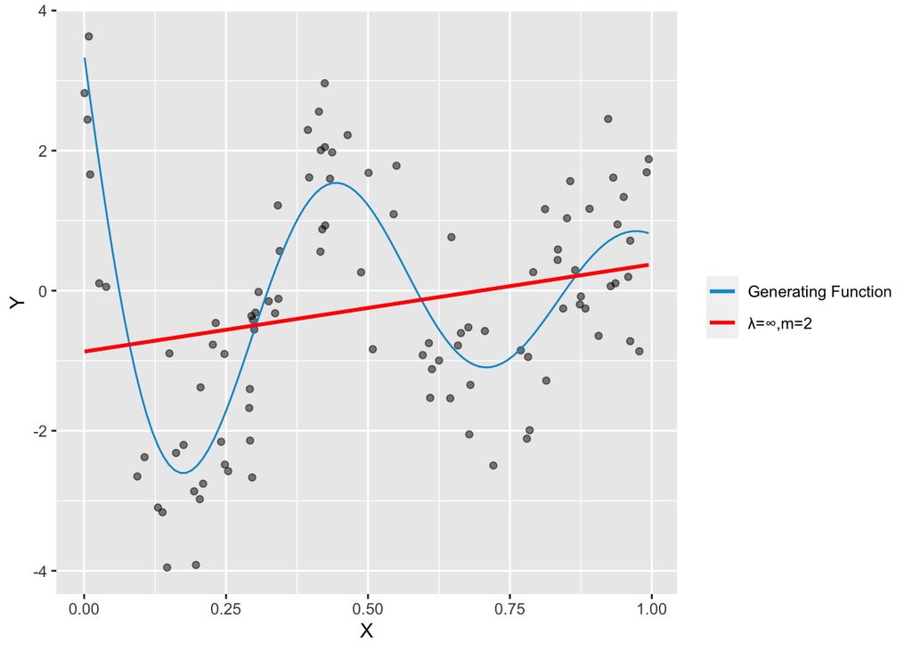

```r
ggplot(df, aes(x = X, y = Y)) +
  geom_point(alpha = 0.5) +
  stat_function(fun = generating_fn, aes(col = "Generating Function")) +
  geom_smooth(method = "lm", formula = "y~x", aes(col = "λ=∞,m=2"), se = F)+
  scale_color_manual(values =c("deepskyblue3", "red")) +
  theme(legend.position = "right", legend.title = element_blank())
```

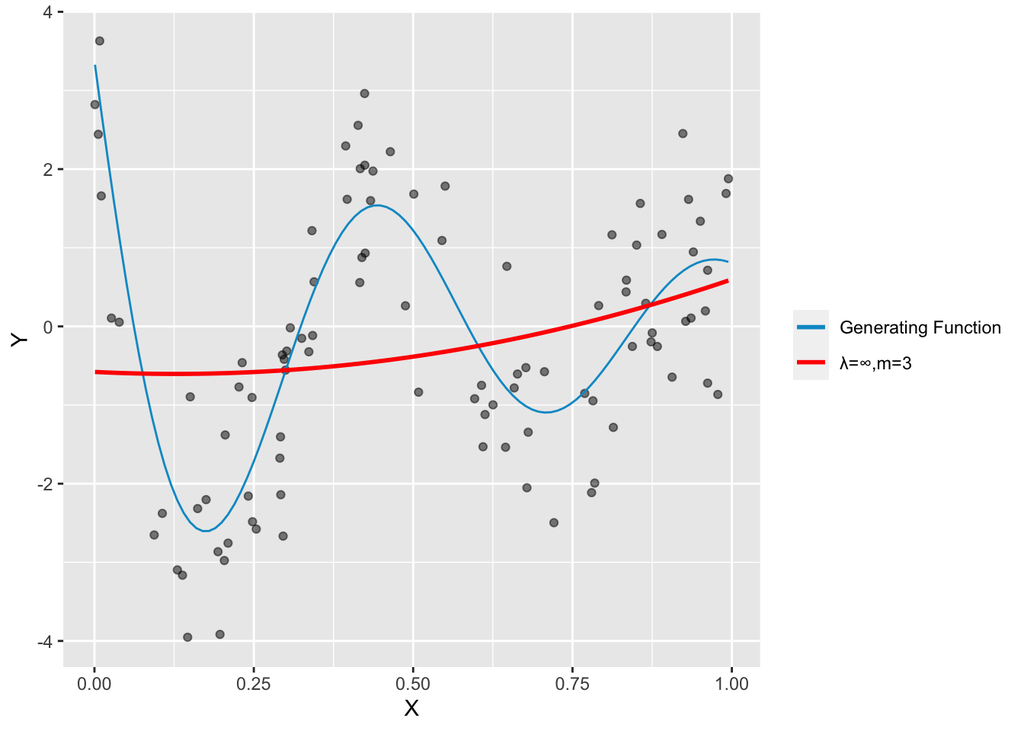

```r
ggplot(df, aes(x = X, y = Y)) +
  geom_point(alpha = 0.5) +
  stat_function(fun = generating_fn, aes(col = "Generating Function")) +
  geom_smooth(method = "lm", formula = "y~x+I(x^2)", aes(col = "λ=∞,m=3"), se = F)+
  scale_color_manual(values =c("deepskyblue3", "red")) +
  theme(legend.position = "right", legend.title = element_blank())
```

e.λ = 0, m = 3

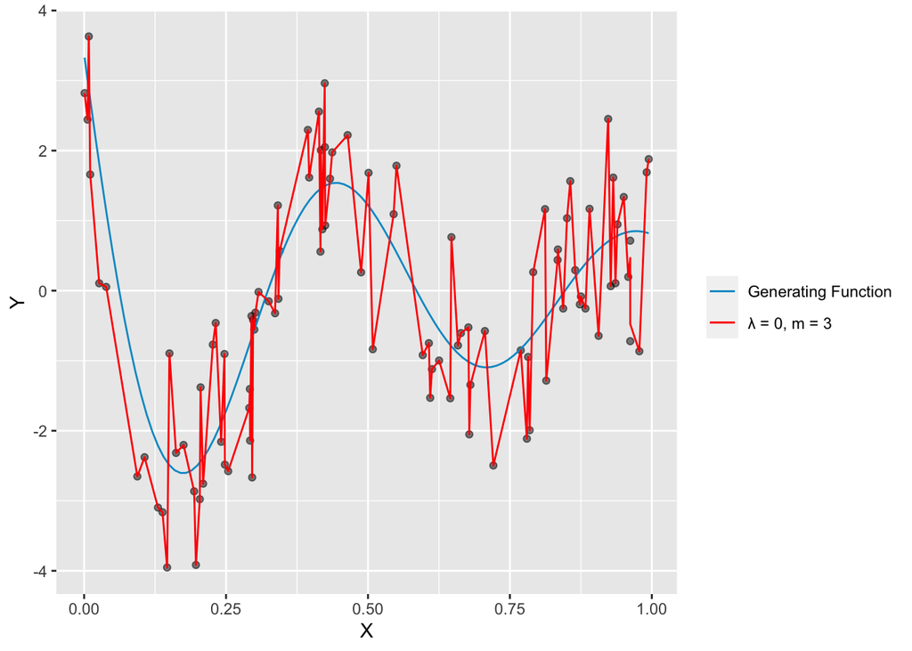

```r
interp_spline <- smooth.spline(x = df$X, y = df$Y, all.knots = T, lambda = 0.0000000000001)
fitted <- predict(interp_spline, x = X)
fitted <- data.frame(x = fitted$x, fitted_y = fitted$y)

ggplot(df, aes(x = X, y = Y)) +
  geom_point(alpha = 0.5) +
  stat_function(fun = generating_fn, aes(col = "Generating Function")) +
  geom_line(data = fitted,
            aes(x=x, y=fitted_y, col="λ = 0, m = 3"))+
  scale_color_manual(values =c("deepskyblue3", "red")) +
  theme(legend.position = "right", legend.title = element_blank())
```

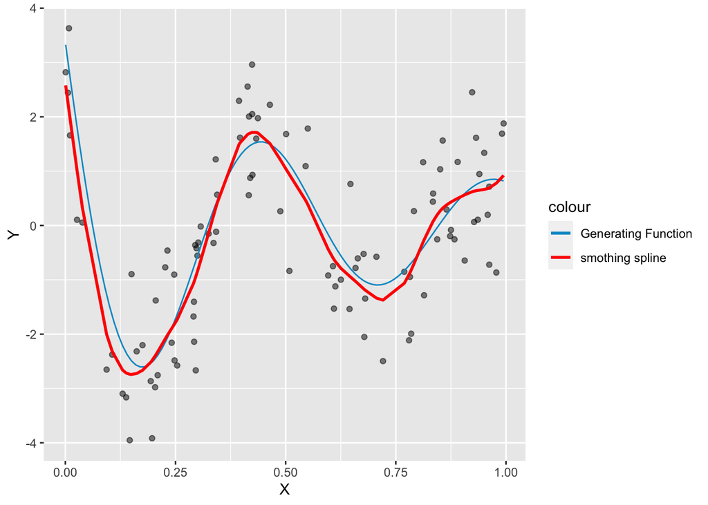

```r
smooth_spline <- smooth.spline(x = df$X, y = df$Y, all.knots = T)
fitted <- predict(smooth_spline, x = X)
fitted <- data.frame(x = fitted$x, fitted_y = fitted$y)

ggplot(df, aes(x = X, y = Y)) +
  geom_point(alpha = 0.5) +
  stat_function(fun = generating_fn, aes(col = "Generating Function")) +
  geom_line(data = fitted,
            aes(x = x, y = fitted_y, col = "smothing spline"), size = 1) +
  scale_color_manual(values = c("deepskyblue3", "red"))
```